# Activity Monitoring

Maisoon

November 19, 2020

```r
knitr::opts_chunk$set(echo = TRUE, fig.path="figures/")
```

# Introduction:

#### We want to record and analyse the steps of an individual per day for two months.

## 1.Loading and preprocessing the data

```r
URL="https://d396qusza40orc.cloudfront.net/repdata%2Fdata%2Factivity.zip"
download.file(URL,destfile="./stepsdata")
unzip("stepsdata")
activity=read.csv("activity.csv")
head(activity)
```

```
##   steps       date interval
## 1    NA 2012-10-01        0
## 2    NA 2012-10-01        5
## 3    NA 2012-10-01       10
## 4    NA 2012-10-01       15
## 5    NA 2012-10-01       20
## 6    NA 2012-10-01       25
```

## 2.What is mean total number of steps taken per day?

### Total number of steps taken per day

```r
activity$date=as.Date(activity$date)  ##change class of date to "Date"
stepsperday=tapply(activity$steps, activity$date, sum)
head(stepsperday)
```

```
## 2012-10-01 2012-10-02 2012-10-03 2012-10-04 2012-10-05 2012-10-06
##         NA        126      11352      12116      13294      15420
```

### Histogram of the total number of steps taken each day

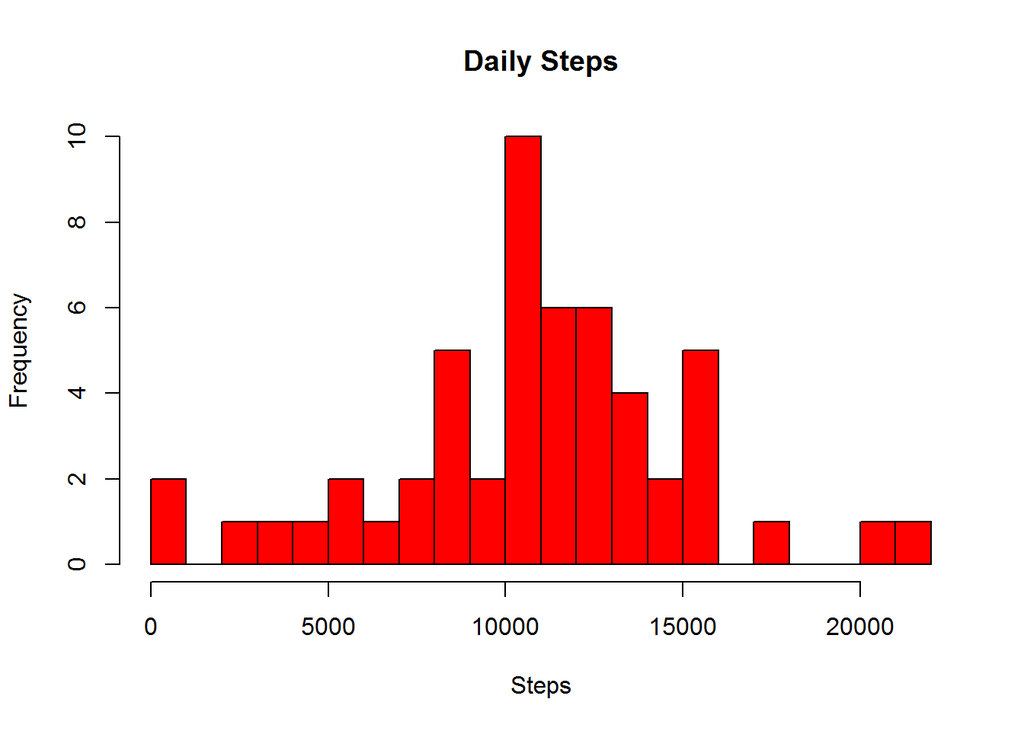

```r
hist(stepsperday,breaks=30,label=FALSE,main="Daily Steps",xlab="Steps",col="red")
```

### Mean and Median of the total number of steps taken per day after removing NA

mean:

```r
mean(stepsperday,na.rm=TRUE)
```

```
## [1] 10766.19
```

median:

```r
median(stepsperday,na.rm=TRUE)
```

```
## [1] 10765
```

## 3. What is the average daily activity pattern?

### Time series plot of the 5-minute interval (x-axis) and the average number of steps taken, averaged across all days (y-axis)

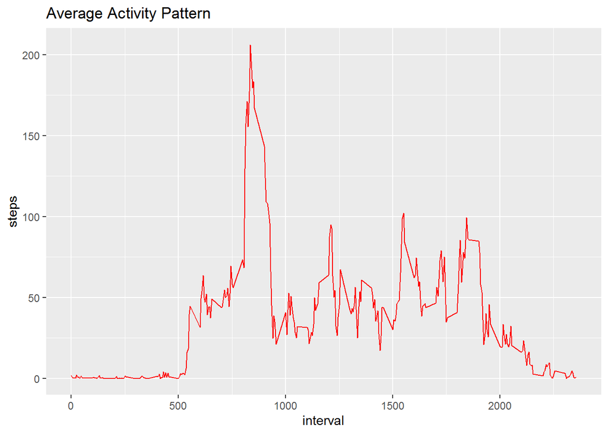

```r
AverageActivity=aggregate(steps~interval,activity,mean,na.rm=TRUE)
library(ggplot2)
ggplot(AverageActivity,aes(interval,steps))+geom_line(col="red")+ggtitle("Average Activity Pattern")
```

### 5-minute interval containing the maximum number of steps

```r
AverageActivity[AverageActivity$steps==max(AverageActivity$steps),1]
```

```
## [1] 835
```

## 4. Imputing missing values

### Total number of missing values in the dataset

```r
sum(is.na(activity$steps))
```

```
## [1] 2304
```

### Filling in all of the missing values in the dataset by using mean of the 5-min interval

```r
merge=merge(activity,AverageActivity,by="interval")
for(i in 1:nrow(activity)){
    if(is.na(merge[i,"steps.x"])){
    merge[i,"steps.x"]=merge[i,"steps.y"]
    }
}
head(merge)
```

```
##   interval  steps.x       date  steps.y
## 1        0 1.716981 2012-10-01 1.716981
## 2        0 0.000000 2012-11-23 1.716981
## 3        0 0.000000 2012-10-28 1.716981
## 4        0 0.000000 2012-11-06 1.716981
## 5        0 0.000000 2012-11-24 1.716981
## 6        0 0.000000 2012-11-15 1.716981
```

### Creating new dataset that is equal to the original dataset but with the missing data filled in

```r
ActivityNoNA=data.frame(steps=merge$steps.x,date=merge$date,interval=merge$interval)
head(ActivityNoNA)
```

```
##      steps       date interval
## 1 1.716981 2012-10-01        0
## 2 0.000000 2012-11-23        0
## 3 0.000000 2012-10-28        0
## 4 0.000000 2012-11-06        0
## 5 0.000000 2012-11-24        0
## 6 0.000000 2012-11-15        0
```

### Histogram of the total number of steps taken each day

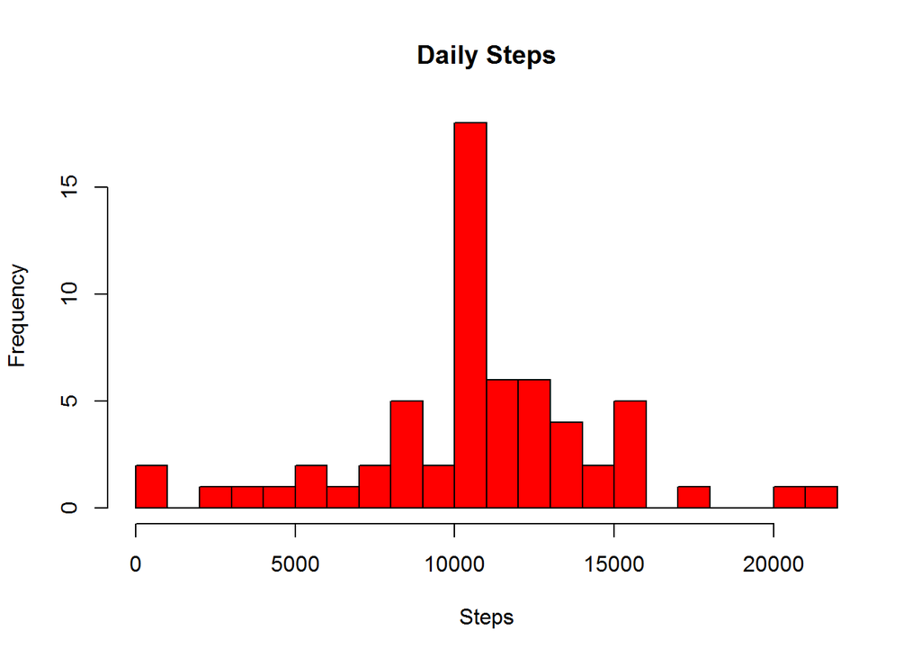

```r
ActivityNoNA$date=as.Date(ActivityNoNA$date)
NoNAstepsperday=with(ActivityNoNA,tapply(steps,date,sum))
hist(NoNAstepsperday,label=FALSE,breaks=30,xlab="Steps",col="red",main="Daily Steps")
```

#### The mean and median total number of steps taken per day after replacing NA

mean:

```r
mean(NoNAstepsperday)
```

```
## [1] 10766.19
```

median:

```r
median(NoNAstepsperday)
```

```
## [1] 10766.19
```

Conclusion:

-The mean of the steps per day stayed the same after the replacements of NA

-The median increased by about 0.01% after the replacements of NA

## 5.Are there differences in activity patterns between weekdays and weekends?

```r
ActivityNoNA$day=rep(NA,nrow(ActivityNoNA))
for(i in 1:nrow(ActivityNoNA)){
                 if(weekdays(ActivityNoNA$date[i])=="Satuday"|
                    weekdays(ActivityNoNA$date[i])=="Sunday"){
                    ActivityNoNA$day[i]="Weekend"
                  }else{
                    ActivityNoNA$day[i]="Weekday"
                  }
}
ActivityNoNA$day=factor(ActivityNoNA$day,labels = c("Weekday","Weekend"))
head(ActivityNoNA)
```

```
##      steps       date interval     day
## 1 1.716981 2012-10-01        0 Weekday
## 2 0.000000 2012-11-23        0 Weekday
## 3 0.000000 2012-10-28        0 Weekend
## 4 0.000000 2012-11-06        0 Weekday
## 5 0.000000 2012-11-24        0 Weekday
## 6 0.000000 2012-11-15        0 Weekday
```

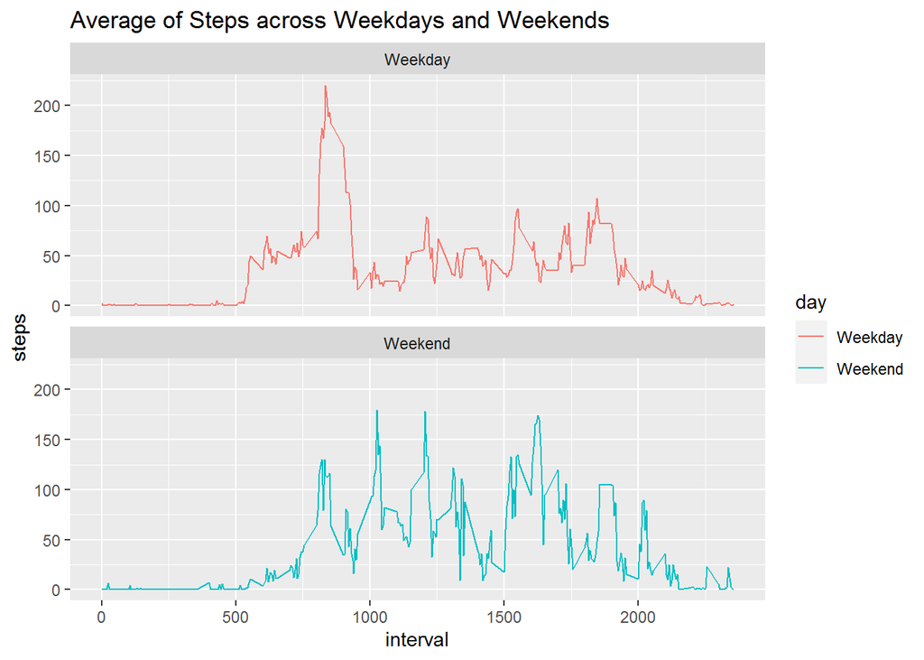

```r
meanperday=aggregate(steps~interval+day,ActivityNoNA,mean)
ggplot(meanperday,aes(interval,steps,color=day))+geom_line()+facet_wrap(.~day,ncol=1,nrow=2)+ggtitle("Average of Steps across Weekdays and Weekends")
```